# Project2Submission

```r
#, include=FALSE}
#download packages
library(tidyverse) #installed tidyverse
library(nlme)
library(ggplot2)
library(here)
library(kableExtra)
library(modelsummary)
library(dplyr)

file_path <- here("analysis_and_plots/heat_flow_ICE_EPFL.csv")

#Load the dataset
data <- read.csv(file_path)

#check data
head(data)
```

```
##   person day session activity sex HF_type HF_value
## 1     F1   1       1  sitting   F   HF_16 44.55319
## 2     F1   1       1  sitting   F    HF_7 75.40033
## 3     F1   1       1  sitting   F    HF_3 34.31703
## 4     F1   1       1  sitting   F    HF_5 59.72419
## 5     F1   1       1  sitting   F    HF_2 47.13543
## 6     F1   1       1  sitting   F    HF_8 46.40537
```

```r
colSums(is.na(data)) #98 NA values
```

```
##   person      day  session activity      sex  HF_type HF_value
##        0        0        0        0        0        0       98
```

```r
nrow(data)
```

```
## [1] 2736
```

```r
#, include=FALSE}
#clean dataset
#drop NAs, order dataset by person, sensor, day, session, activity
data_clean <- data %>%
  drop_na() %>%
  mutate(
    person = as.factor(person),
    day = factor(day, levels = c("1", "2")),
    session = factor(session, levels = c("1", "2", "3", "4")),
    activity = factor(activity, levels = c("sitting", "standing", "walking")),
    sex = as.factor(sex),
    HF_type = as.factor(HF_type),
    sensor_num = as.numeric(HF_type),
    session_num = as.numeric(session),
    Block_ID = as.factor(paste(person, day, session, activity, sep="_"))
  ) %>%
  arrange(person, HF_type, day, session, activity)
```

```r
#, include=FALSE}
# baselines
levels(data_clean$sex)[1] #F
```

```
## [1] "F"
```

```r
levels(data_clean$activity)[1] #sitting
```

```
## [1] "sitting"
```

```r
levels(data_clean$day)[1] #1
```

```
## [1] "1"
```

```r
levels(data_clean$session)[1] #1
```

```
## [1] "1"
```

```r
levels(data_clean$HF_type)[1]  #HF_16
```

```
## [1] "HF_16"
```

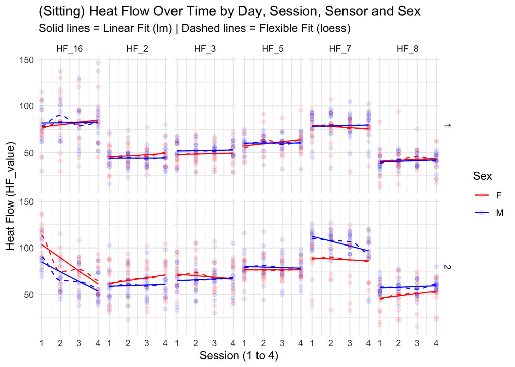

```r
#, include=FALSE}
# make session to be continuous variable for now
# spaghetti plot + faceting
data_sitting <- data_clean %>%
  filter(activity == "sitting")

ggplot(data_sitting, aes(x = session_num, y = HF_value, color = sex)) +
  geom_point(alpha = 0.1) +
  # Flexible LOESS curves
  geom_smooth(method = "loess", formula = y ~ x, se = FALSE, linetype = "dashed", linewidth = 0.5) +
  # Straight Linear regression lines
  geom_smooth(method = "lm", formula = y ~ x, se = FALSE, linetype = "solid", linewidth = 0.5) +
  # Grid layout
  facet_grid(day ~ HF_type) +
  # Colors
  scale_color_manual(values = c("M" = "blue", "F" = "red")) +
  theme_minimal() +
  labs(
    title = "(Sitting) Heat Flow Over Time by Day, Session, Sensor and Sex",
    subtitle = "Solid lines = Linear Fit (lm) | Dashed lines = Flexible Fit (loess)",
    x = "Session (1 to 4)",
    y = "Heat Flow (HF_value)",
    color = "Sex"
  )
```

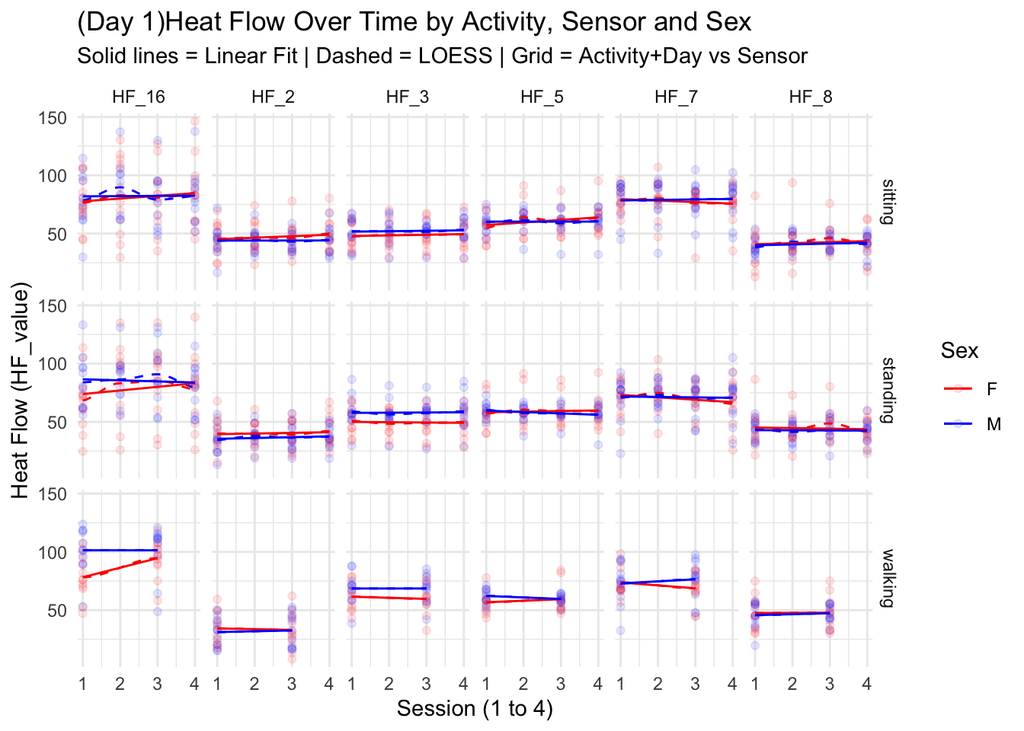

```r
#, include=FALSE}

data_day1 <- data_clean %>% filter(day == "1")

ggplot(data_day1, aes(x = session_num, y = HF_value, color = sex)) +
  geom_point(alpha = 0.1) +

  geom_smooth(method = "loess", formula = y ~ x, se = FALSE, linetype = "dashed", size = 0.5) +

  # Straight Linear regression lines (Solid lines, one for M and one for F)
  geom_smooth(method = "lm", formula = y ~ x, se = FALSE, linetype = "solid", size = 0.5) +

  facet_grid(activity ~ HF_type) +

  scale_color_manual(values = c("M" = "blue", "F" = "red")) +

  theme_minimal() +
  labs(
    title = "(Day 1)Heat Flow Over Time by Activity, Sensor and Sex",
    subtitle = "Solid lines = Linear Fit | Dashed = LOESS | Grid = Activity+Day vs Sensor",
    x = "Session (1 to 4)",
    y = "Heat Flow (HF_value)",
    color = "Sex"
  )
```

```r
#Since all variables are categorical, we don't need to check for linearity assumption.

#But above plot indicates there is fixed effect from every categorical variables. We should include all of them in our model.

#(no need to test if each fixed effect exists, just from plot and intuition, also since fixed effects are the same, in later models we can use REML which doesn't influence comparison)
```

## Section 5: Results

## Section 5.1: Initial Model

```r
#, include=FALSE}

naive_lm <- lm(HF_value ~ session + activity + day + HF_type + sex, data = data_clean)

summary(naive_lm)
```

```
##
## Call:
## lm(formula = HF_value ~ session + activity + day + HF_type +
##     sex, data = data_clean)
##
## Residuals:
##     Min      1Q  Median      3Q     Max
## -79.530 -10.704  -0.129  11.157  77.121
##
## Coefficients:
##                  Estimate Std. Error t value Pr(>|t|)
## (Intercept)       72.3069     1.2999  55.624  < 2e-16 ***
## session2          -0.3232     1.2009  -0.269 0.787869
## session3          -1.0986     0.9248  -1.188 0.235003
## session4          -3.1023     1.0837  -2.863 0.004233 **
## activitystanding  -2.1447     0.8419  -2.547 0.010914 *
## activitywalking    2.0898     1.0664   1.960 0.050146 .
## day2              12.7357     0.7443  17.111  < 2e-16 ***
## HF_typeHF_2      -29.9354     1.2712 -23.549  < 2e-16 ***
## HF_typeHF_3      -12.9806     1.2799 -10.142  < 2e-16 ***
## HF_typeHF_5       -9.9628     1.2860  -7.747 1.33e-14 ***
## HF_typeHF_7        4.4112     1.2664   3.483 0.000503 ***
## HF_typeHF_8      -26.9716     1.2748 -21.158  < 2e-16 ***
## sexM               2.2649     0.7360   3.077 0.002111 **
## ---
## Signif. codes:  0 '***' 0.001 '**' 0.01 '*' 0.05 '.' 0.1 ' ' 1
##
## Residual standard error: 18.9 on 2625 degrees of freedom
## Multiple R-squared:  0.3705, Adjusted R-squared:  0.3677
## F-statistic: 128.8 on 12 and 2625 DF,  p-value: < 2.2e-16
```

```r
#Also based on the significance for each coefficients, we should include all of the predictors.
```

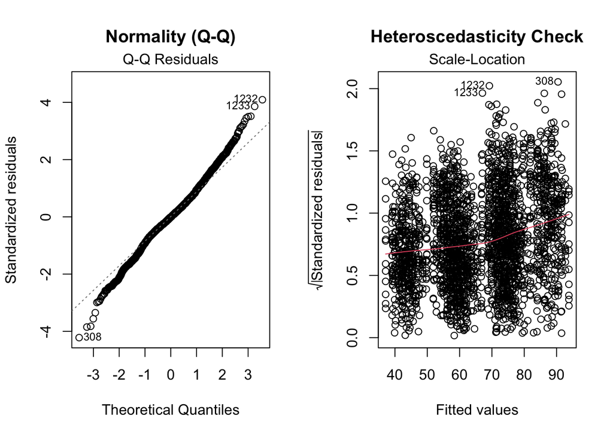

```r
#, include=FALSE}
par(mfrow = c(1, 2)) #1 row 2 columns

# Plot 2: Normal Q-Q
plot(naive_lm, which = 2, main = "Normality (Q-Q)")

# Plot 3: Scale-Location (Spread-Location)
plot(naive_lm, which = 3, main = "Heteroscedasticity Check")
```

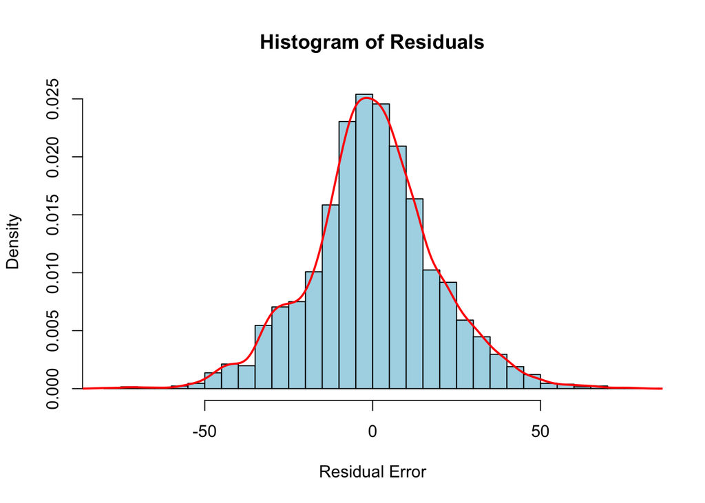

```r
#, include=FALSE}
par(mfrow = c(1, 1)) #reset plotting to 1, 1

hist(resid(naive_lm), breaks = 30, probability = TRUE, col = "lightblue", main = "Histogram of Residuals", xlab = "Residual Error")
lines(density(resid(naive_lm)), col = "red", lwd = 2)
```

```r
#, include=FALSE}
log_naive_lm <- lm(log(HF_value) ~ session + activity + day + HF_type + sex, data = data_clean)
summary(log_naive_lm)
```

```
##
## Call:
## lm(formula = log(HF_value) ~ session + activity + day + HF_type +
##     sex, data = data_clean)
##
## Residuals:
##      Min       1Q   Median       3Q      Max
## -2.09094 -0.14471  0.03708  0.20098  0.81742
##
## Coefficients:
##                    Estimate Std. Error t value Pr(>|t|)
## (Intercept)       4.2059986  0.0220531 190.721  < 2e-16 ***
## session2         -0.0002083  0.0203732  -0.010  0.99184
## session3         -0.0087793  0.0156898  -0.560  0.57583
## session4         -0.0375880  0.0183842  -2.045  0.04100 *
## activitystanding -0.0374859  0.0142836  -2.624  0.00873 **
## activitywalking   0.0138636  0.0180920   0.766  0.44358
## day2              0.2073803  0.0126274  16.423  < 2e-16 ***
## HF_typeHF_2      -0.5116352  0.0215655 -23.725  < 2e-16 ***
## HF_typeHF_3      -0.1751289  0.0217134  -8.065 1.10e-15 ***
## HF_typeHF_5      -0.1060988  0.0218168  -4.863 1.22e-06 ***
## HF_typeHF_7       0.0626621  0.0214838   2.917  0.00357 **
## HF_typeHF_8      -0.4176090  0.0216262 -19.310  < 2e-16 ***
## sexM              0.0369273  0.0124864   2.957  0.00313 **
## ---
## Signif. codes:  0 '***' 0.001 '**' 0.01 '*' 0.05 '.' 0.1 ' ' 1
##
## Residual standard error: 0.3206 on 2625 degrees of freedom
## Multiple R-squared:  0.3549, Adjusted R-squared:  0.352
## F-statistic: 120.4 on 12 and 2625 DF,  p-value: < 2.2e-16
```

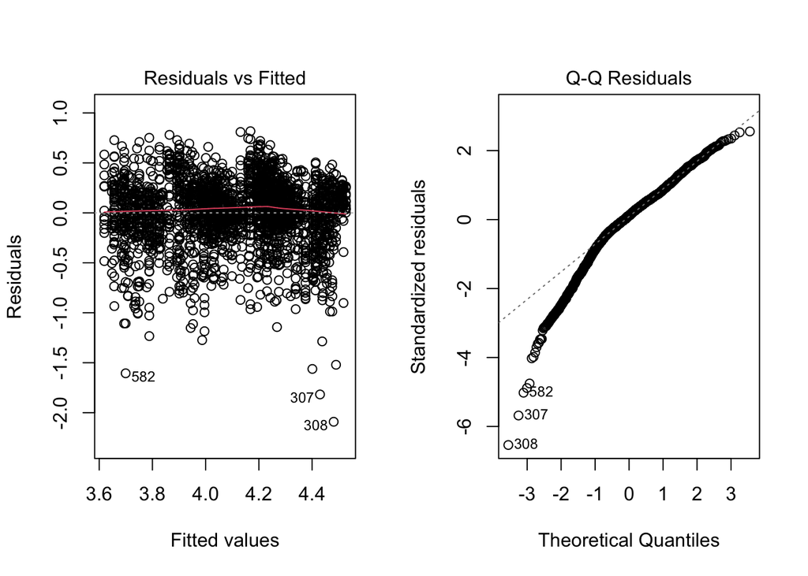

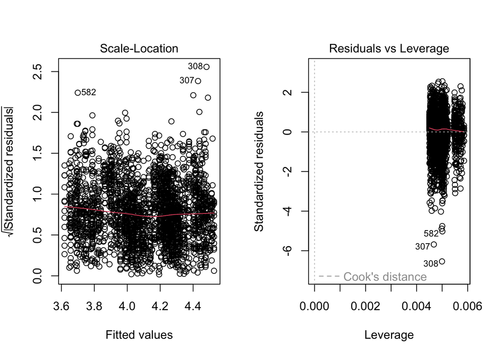

```r
par(mfrow = c(1, 2))
plot(log_naive_lm)
```

so we do log transformation

(To address the heteroscedasticity observed in the initial raw-scale model, a natural logarithm transformation was applied to the response variable ($\log(\text{HF_value})$). Post-transformation diagnostics reveal a significant improvement in the model’s structural validity.)

Applying a log transformation to the response variable resolved the heteroscedasticity observed in the initial model. While the residuals still exhibit a slightly heavier lower tail, the transformation successfully resolved severe heteroscedasticity present in the untransformed data, which is the higher priority for valid statistical inference. Subsequent analyses are conducted on the log scale.

An initial linear model, $\text{HF_value ~ session + activity + day + HF_type + sex}$ results in residuals that are approximately normal but have heteroscedascity, as seen in Figure 2. Applying a natural logarithmic transformation to the response variable ($\log(\text{HF_value})$) removes the heteroscedascity

## Section 5.2: Fixed Interaction Terms

```r
log_naive_lm <- lm(log(HF_value) ~ session + activity + day + HF_type + sex, data = data_clean)
no_session <- lm(log(HF_value) ~ activity + day + HF_type + sex, data = data_clean)

anova(no_session, log_naive_lm)
```

```
## Analysis of Variance Table
##
## Model 1: log(HF_value) ~ activity + day + HF_type + sex
## Model 2: log(HF_value) ~ session + activity + day + HF_type + sex
##   Res.Df    RSS Df Sum of Sq      F Pr(>F)
## 1   2628 270.29
## 2   2625 269.77  3   0.51558 1.6723 0.1708
```

```r
drop1(log_naive_lm, test = "F")
```

```
## Single term deletions
##
## Model:
## log(HF_value) ~ session + activity + day + HF_type + sex
##          Df Sum of Sq    RSS     AIC  F value  Pr(>F)
## <none>                269.77 -5989.2
## session   3     0.516 270.29 -5990.1   1.6723 0.17085
## activity  2     1.104 270.88 -5982.4   5.3734 0.00469 **
## day       1    27.719 297.49 -5733.2 269.7184 < 2e-16 ***
## HF_type   5   116.796 386.57 -5050.2 227.2962 < 2e-16 ***
## sex       1     0.899 270.67 -5982.4   8.7462 0.00313 **
## ---
## Signif. codes:  0 '***' 0.001 '**' 0.01 '*' 0.05 '.' 0.1 ' ' 1
```

```r
log_naive_nosession <- lm(log(HF_value) ~ activity + day + HF_type + sex, data = data_clean)
```

we drop session at this stage

## Interaction terms

example interpretation: activty * sensor

No interaction (Additive): The gap between Sensor 1 and Sensor 2 is rigidly locked at +5, forever, no matter what activity is happening.

With interaction: The gap between Sensor 1 and Sensor 2 is allowed to stretch or shrink depending on the activity (e.g., it’s +5 during walking, but it shrinks to +3 during sitting).

```r
m_add_ML <- lm(log(HF_value) ~ day + activity + sex + HF_type,
                data = data_clean)

# all 10 possible two-way interactions
interactions <- c("day:session", "day:activity", "day:sex", "day:HF_type", "session:activity", "session:sex", "session:HF_type", "activity:sex", "activity:HF_type", "sex:HF_type")

# vector to store the p-values
p_values <- numeric(length(interactions))
base_formula <- "log(HF_value) ~ day + activity + sex + HF_type"

# Loop through each interaction, run the model, and run anova test
for(i in 1:length(interactions)) {
  new_formula <- as.formula(paste(base_formula, "+", interactions[i]))
  m_temp <- update(m_add_ML, formula = new_formula)
  anv_result <- anova(m_add_ML, m_temp)
  p_values[i] <- anv_result$"Pr(>F)"[2]
}

# sort from most to least significant
results_table <- data.frame(
  Interaction = interactions,
  P_Value = round(p_values, 5)
)
results_table <- results_table[order(results_table$P_Value), ]

print(results_table)
```

```
##         Interaction P_Value
## 4       day:HF_type 0.00000
## 7   session:HF_type 0.00000
## 9  activity:HF_type 0.00000
## 10      sex:HF_type 0.00010
## 1       day:session 0.01218
## 8      activity:sex 0.18135
## 5  session:activity 0.33179
## 6       session:sex 0.37008
## 3           day:sex 0.42763
## 2      day:activity 0.82929
```

To identify relevant interaction terms for the fixed-effects structure, a preliminary screening of ten two-way interactions was conducted.

To test whether the addition of the interaction term significantly improves the model (Null Hypothesis ($H_0$): The coefficient for the interaction term is exactly zero ($\beta_{interaction} = 0$)), the test calculates the F-statistic using the Residual Sum of Squares (RSS) from both models:
$$F =
\frac{(RSS_{reduced} - RSS_{full}) / (p_{full} -
p_{reduced})}{RSS_{full} / (n - p_{full})}$$
(!!Family Wise Error Rate need correction)

Because conducting multiple simultaneous hypothesis tests artificially inflates the probability of Type I errors (false positives), a Bonferroni correction was applied to strictly control the family-wise error rate (FWER). Based on a standard family-wise alpha level of 0.05 distributed across 10 tests, the adjusted significance threshold was established at p < 0.005. Consequently, only interactions falling below this rigorous threshold are statistically significant.

We keep the interaction terms “day:HF_type”, “session:HF_type”, “activity:HF_type”, “sex:HF_type”

Now we add all of them and check their significance (Backward Elimination)

A marginal backward elimination procedure (using partial F-tests) was conducted on the saturated fixed-effects model. The results demonstrated that all four tested two-way interactions with the sensor type (HF_type) were highly significant ($p < 0.005$ across all terms). Consequently, no terms were eliminated. This definitively proves that the physiological measurements from the different sensors are not parallel; rather, each sensor possesses a unique, highly specific thermal profile that reacts differently to the day, session time, physical activity, and biological sex of the participant.

Also because of this, we add session back to the main effect.

```r
m_full_lm <- lm(log(HF_value) ~ (day + session + activity + sex) * HF_type,
                data = data_clean)

drop1(m_full_lm, test = "F")
```

```
## Single term deletions
##
## Model:
## log(HF_value) ~ (day + session + activity + sex) * HF_type
##                  Df Sum of Sq    RSS     AIC F value    Pr(>F)
## <none>                        226.43 -6381.2
## day:HF_type       5   19.3895 245.82 -6174.4 44.3563 < 2.2e-16 ***
## session:HF_type  15    3.0888 229.52 -6375.4  2.3553  0.002318 **
## activity:HF_type 10   14.2155 240.65 -6240.5 16.2600 < 2.2e-16 ***
## sex:HF_type       5    2.5916 229.03 -6361.1  5.9286 1.856e-05 ***
## ---
## Signif. codes:  0 '***' 0.001 '**' 0.01 '*' 0.05 '.' 0.1 ' ' 1
```

(drop1() tests every single variable as if it were the very last variable in the model.

To test day:HF_type, it puts all other main effects and interactions into the model first, gives them all the variance they want, and then asks: “Does day:HF_type add anything uniquely new to the very end?”

Then, it resets the math. To test sex:HF_type, it puts everything else in first, and asks: “Does sex:HF_type add anything uniquely new to the very end?”)

(drop1() only tests terms that can be removed without breaking model hierarchy. So drop1() does not test removing those main effects.)

**Math Section:**

To rigorously determine the final fixed-effects structure and avoid the order-dependence issues inherent to sequential testing, a marginal backward elimination procedure was implemented.

This was executed using Partial F-tests to evaluate the significance of each two-way interaction term given the presence of all other terms in the saturated model.

For each interaction term with $r$ degrees of freedom (which corresponds to $k-1$ coefficients for a categorical variable with $k$ levels), the null hypothesis posited that all associated coefficients were simultaneously zero ($H_0: \beta_1 = \dots = \beta_r = 0$).

The test statistic was computed as:
$$F =
\frac{(RSS_{reduced} - RSS_{full}) / r}{RSS_{full} / (n - p)}$$
Under the null hypothesis, this statistic follows an $F_{r, n-p}$ distribution. The validity of this test assumes independent, identically distributed, and normal errors, $\epsilon \sim N(0, \sigma^2)$.

Variables failing to meet the significance threshold ($p < 0.05$) under this marginal evaluation were to be eliminated; however, all four interaction terms demonstrated highly significant F-statistics, confirming their unique and non-redundant explanatory power.

## Residual plot from fixed-effect-only linear model

justify adding random intercept

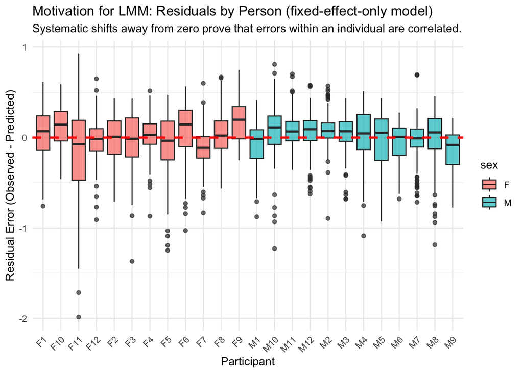

```r
m0 <- lm(log(HF_value) ~ (day + session + activity + sex) * HF_type,
         data = data_clean)
# residuals added to dataframe
data_clean$residuals <- resid(m0)

ggplot(data_clean, aes(x = person, y = residuals, fill = sex)) +
  geom_boxplot(alpha = 0.7) +
  # red line: perfect independent residuals should be centered at 0
  geom_hline(yintercept = 0, color = "red", linetype = "dashed", size = 1) +
  theme_minimal() +
  theme(axis.text.x = element_text(angle = 45, hjust = 1)) +
  labs(
    title = "Motivation for LMM: Residuals by Person (fixed-effect-only model)",
    subtitle = "Systematic shifts away from zero prove that errors within an individual are correlated.",
    x = "Participant",
    y = "Residual Error (Observed - Predicted)"
  )
```

The boxplot of the naive linear model’s residuals reveals that the mean error for individual participants systematically deviates from zero. This indicates that unobserved subject-specific traits are causing residuals within the same individual to share the same direction and magnitude. This proves that intra-subject (within the same person) observations are correlated, motivating the inclusion of a random intercept for the participant.

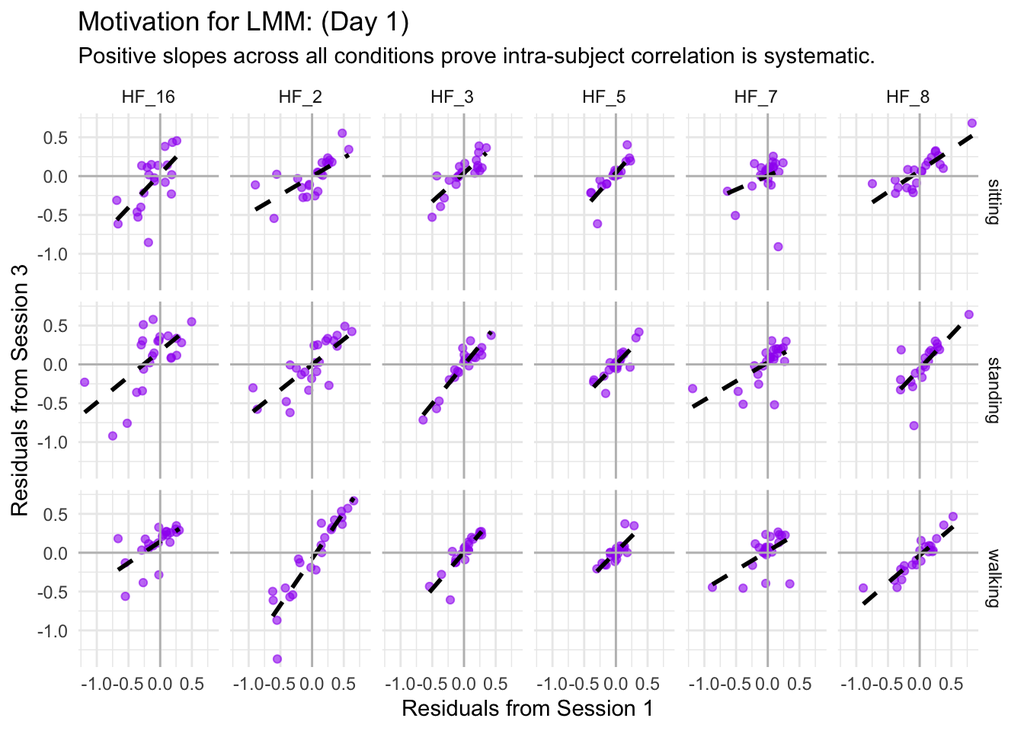

```r
residuals_wide_facet <- data_clean %>%
  # Filter to just Day 1
  filter(day == "1") %>%
  select(person, activity, HF_type, session, residuals) %>%
  pivot_wider(names_from = session, values_from = residuals, names_prefix = "Session_")

ggplot(residuals_wide_facet, aes(x = Session_1, y = Session_3)) +
  geom_point(alpha = 0.6, color = "purple") +
  geom_smooth(method = "lm", formula = y ~ x, color = "black", linetype = "dashed", se = FALSE) +
  geom_hline(yintercept = 0, color = "gray") +
  geom_vline(xintercept = 0, color = "gray") +
  facet_grid(activity ~ HF_type) +
  theme_minimal() +
  labs(
    title = "Motivation for LMM: (Day 1)",
    subtitle = "Positive slopes across all conditions prove intra-subject correlation is systematic.",
    x = "Residuals from Session 1",
    y = "Residuals from Session 3"
  )
```

# Optimizing the random structure

## Random Intercept Model

```r
library(nlme)
m1 <- lme(fixed = log(HF_value) ~ (day + session + activity + sex) * HF_type,
          random = ~ 1 | person, #unique intercept for each person
          data = data_clean,
          method = "REML")

#summary(m1)
```

$$\begin{aligned}
Y_{ij} &= \beta_0 + \beta_1 \text{Day}_{ij} + \beta_2
\text{Session}_{ij} + \beta_3 \text{Activity}_{ij} + \beta_4
\text{Sex}_{i} + \beta_5 \text{HF_type}_{ij} \\
&+ \gamma_1 (\text{Day}_{ij} \times \text{HF_type}_{ij}) + \gamma_2
(\text{Session}_{ij} \times \text{HF_type}_{ij}) + \gamma_3
(\text{Activity}_{ij} \times \text{HF_type}_{ij}) \\
&+ \gamma_4 (\text{Sex}_{i} \times \text{HF_type}_{ij}) + b_i +
\epsilon_{ij}
\end{aligned}$$
$Y_{ij}$: The log(Heat Flow) for person $i$ at measurement $j$.

$\beta_0$: The global fixed intercept, representing the expected mean heat flow for a female participant while sitting during Session 1 on Day 1, as measured by sensor HF_16.

$\beta_1 \dots \beta_5$: The fixed main-effect coefficients associated with the covariates: Day, Session, Activity, Sex, and Sensor Type. For categorical predictors, these coefficients represent the estimated differences in the marginal mean relative to the reference baseline specifically for the baseline sensor type.

$\gamma_1 \dots \gamma_4$: The fixed-effect coefficients for the two-way interactions. They quantify how the effects of Day, Session, Activity, and Sex deviate from their baseline effects when measured by a non-baseline sensor type.

$b_i$: The random intercept for person $i$. This is the subject-specific baseline shift.

$\epsilon_{ij}$: The residual error for that specific observation.

Assumptions:

$b_i \sim \mathcal{N}(0, d)$: The random intercepts are normally distributed around a mean of 0, with variance $d$;

$\epsilon_{ij} \sim \mathcal{N}(0, \sigma^2)$: The residual errors are normally distributed with a mean of 0 and variance $\sigma^2$;

$b_i$ and $\epsilon_{ij}$ are independent of each other.

We then get compound symmetry correlation structure:

$$Cov(Y_{ij}, Y_{ik}) = d + \sigma^2
I(j=k)$$
$$Corr(Y_{ij}, Y_{ik}) =
\frac{d}{d+\sigma^2}, j\not= k$$

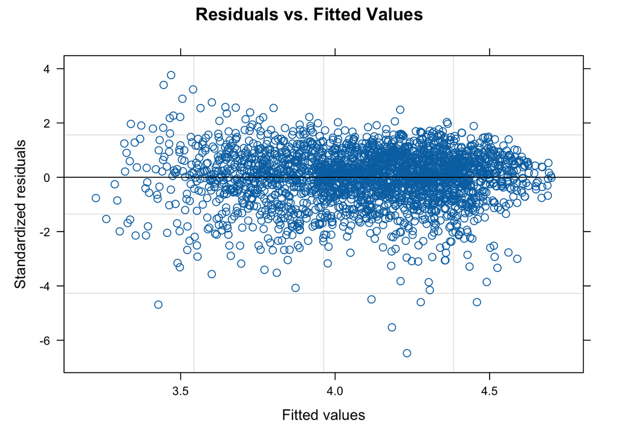

```r
# Check constant variance
plot(m1, main = "Residuals vs. Fitted Values")
```

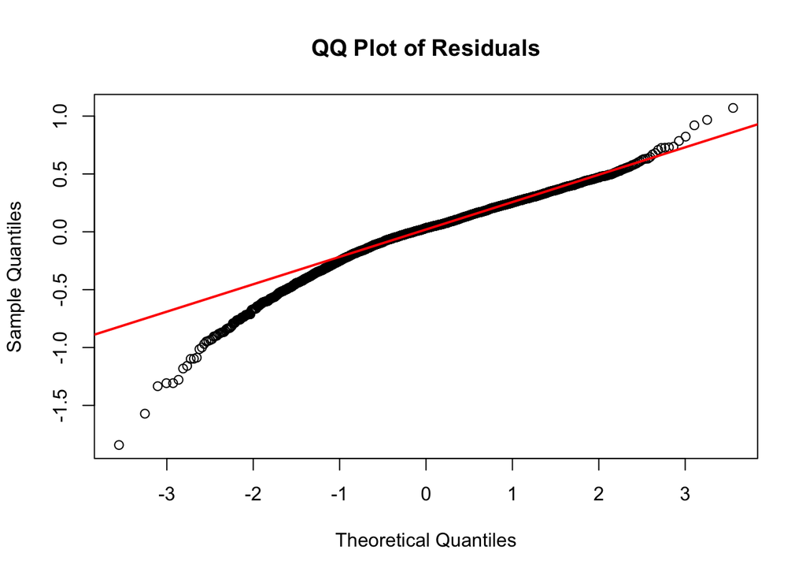

```r
# check normality
qqnorm(resid(m1), main = "QQ Plot of Residuals")
qqline(resid(m1), col = "red", lwd = 2)
```

Visual inspection of the Normal Q-Q plot of the residuals indicates that the normality assumption is generally satisfied for the most of the data. However, the plot reveals deviation at the lower tail. Given the robustness of linear mixed models to moderate non-normality and our large sample size, the model fit is acceptable, though the presence of these extreme residual values is noted.

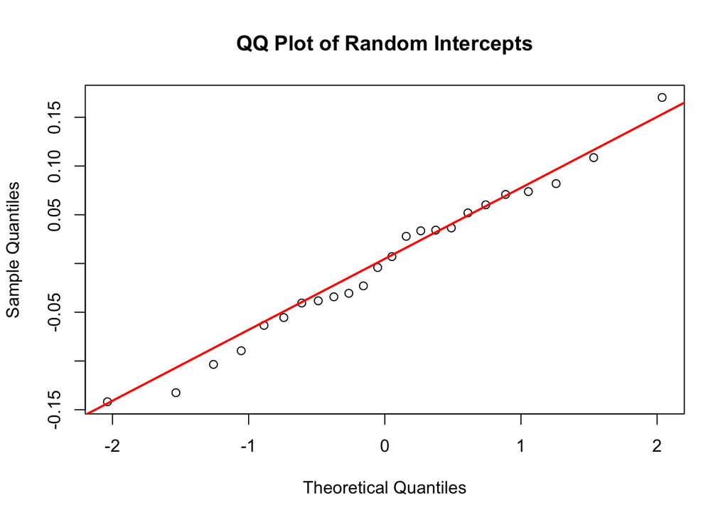

```r
random_intercepts <- ranef(m1)$'(Intercept)'
qqnorm(random_intercepts, main = "QQ Plot of Random Intercepts")
qqline(random_intercepts, col = "red", lwd = 2)
```

### Nested Model

We postulate that heat flow has unobserved heterogeneity not only between individuals, but also across different physical activities within the same individual. The initial random intercept model assumes a single, constant baseline shift for each participant across all experimental conditions. However, it is biologically plausible that a participant’s underlying baseline heat flow during a high-exertion activity (e.g., walking) differs fundamentally from their baseline during a resting state (e.g., sitting).

To account for this hierarchical variance, a nested random-effects structure (~ 1 | person/activity) was hypothesized and tested. This is designed to capture the intra-individual correlation expected among measurements taken during the identical physical activity.

(more explanation: e.g. every single person has a unique, personal reaction to walking that differs from the population average. if F1 is a professional athlete. Her general resting baseline might be higher than average (+2), but because she is so fit, walking requires zero effort for her. When she walks, her heat flow barely rises at all)

Observations from the same person doing the same activity are now more highly correlated than observations from the same person doing different activities. (The nested model allows the correlation to be “tighter” when the conditions match exactly, and “looser” when the activity changes)

(need both $b_i + b_{ij}$: if drop $b_i$, the model assumes that F1-Sitting and F1-Walking share absolutely nothing in common.)

```r
m2 <- lme(fixed = log(HF_value) ~ (day + session + activity + sex) * HF_type,
          random = ~ 1 | person/activity,
          data = data_clean,
          method = "REML")

#summary(m2)
```

Let $Y_{ijk}$ represent the $\log(\text{HF_value})$ for person $i$, during activity $j$, at specific measurement instance $k$.

$$\begin{aligned}
Y_{ijk} &= \beta_0 + \beta_1 \text{Day}_{ijk} + \beta_2
\text{Session}_{ijk} + \beta_3 \text{Activity}_{j} + \beta_4
\text{Sex}_{i} + \beta_5 \text{HF_type}_{ijk} \\
&+ \gamma_1 (\text{Day}_{ijk} \times \text{HF_type}_{ijk}) +
\gamma_2 (\text{Session}_{ijk} \times \text{HF_type}_{ijk}) + \gamma_3
(\text{Activity}_{j} \times \text{HF_type}_{ijk}) + \gamma_4
(\text{Sex}_{i} \times \text{HF_type}_{ijk}) \\
&+ b_i + b_{ij} + \epsilon_{ijk}
\end{aligned}$$
**Fixed Effects ($\beta$ and $\gamma$):**

$\beta_0$: The population-level fixed intercept. This represents the expected mean log-transformed heat flow for the reference group (a Female participant, Sitting, during Session 1 on Day 1, as measured by sensor HF_16).

$\beta_1 \dots \beta_5$: The population-level fixed-effect coefficients associated with the experimental covariates (main effects). For categorical predictors, these represent the estimated marginal mean differences relative to the reference baseline, *specifically for the baseline sensor type.*

$\gamma_1 \dots \gamma_4$: The fixed-effect interaction coefficients. These quantify how the effects of Day, Session, Activity, and Sex deviate from their baseline effects when measured by a non-baseline sensor type.

**Random Effects ($b$):**

$b_i$: The subject-level random intercept for person $i$. This captures the unobserved heterogeneity between individuals, representing how person $i$’s overall baseline differs from the population average.

$b_{ij}$: The activity-level random intercept for activity $j$ nested within person $i$. This captures the unique, intra-individual deviation for a specific activity, allowing the model to account for the higher correlation among measurements taken during the identical physical task.

**Residual Error ($\epsilon$):**

$\epsilon_{ijk}$: The residual error for observation $k$, capturing the remaining unexplained variance for that specific measurement instance, after accounting for both fixed covariates and nested random structures.

**Distributional Assumptions:**

$b_i \sim \mathcal{N}(0, d_1)$,

$b_{ij} \sim \mathcal{N}(0, d_2)$,

$\epsilon_{ijk} \sim \mathcal{N}(0, \sigma^2)$

$b_i$, $b_{ij}$, and $\epsilon_{ijk}$ are mutually independent of one another.

**Variance and Covariance Structure:**

$$Var(Y_{ijk}) = d_1 + d_2 +
\sigma^2$$

The covariance between any two measurements ($Y_{ijk}$ and $Y_{ij'k'}$) from the exact same person $i$ depends on whether those measurements were taken during the same physical activity. Let $I(\cdot)$ be an indicator function that equals $1$ if the condition is true and $0$ if false:

$$Cov(Y_{ijk}, Y_{ij'k'}) = d_1 +
d_2 I(j=j') + \sigma^2 I(j=j', k=k')$$

#### Check whether this is needed by looking at the proportion of variance explained by the different levels.

```r
VarCorr(m1)
```

```
## person = pdLogChol(1)
##             Variance    StdDev
## (Intercept) 0.006945276 0.08333832
## Residual    0.080883753 0.28440069
```

Proportion of variance explained by the random intercept = 0.006945276/(0.006945276+0.080883753)

```r
VarCorr(m2)
```

```
##             Variance     StdDev
## person =    pdLogChol(1)
## (Intercept) 6.945276e-03 8.333832e-02
## activity =  pdLogChol(1)
## (Intercept) 2.265352e-10 1.505109e-05
## Residual    8.088375e-02 2.844007e-01
```

```r
anova(m1, m2)
```

```
##    Model df      AIC      BIC    logLik   Test      L.Ratio p-value
## m1     1 50 1207.812 1500.783 -553.9061
## m2     2 51 1209.812 1508.642 -553.9061 1 vs 2 1.010276e-06  0.9992
```

m1 has lower AIC and BIC; also the likelihood ratio test shows that we do not reject m1.

### Other nested models: (another random intercept sensor type | person)

Furthermore, we hypothesized that unobserved heterogeneity exists not only at the individual level but also at the specific sensor-placement level within each participant. While the fixed effects account for the population-average thermal differences between sensor types, and the person-level random intercept accounts for an individual’s overall global baseline, a participant might exhibit different baseline shifts for specific sensors. For example, physical traits like skin thickness, or simply how tightly a specific sensor is strapped to the body, could make that exact sensor consistently read higher or lower for a person, regardless of their overall body temperature.

To account for this variance, an alternative nested random-effects structure (~ 1 | person/HF_type) was tested. This hierarchical formulation is designed to capture the additional intra-individual correlation expected among repeated measurements taken by the exact same physical sensor on the exact same person, allowing each sensor to possess its own unique random deviation within the subject’s overall baseline profile.

```r
m2_HFtype <- lme(fixed = log(HF_value) ~ (day + session + activity + sex) * HF_type,
          random = ~ 1 | person/HF_type,
          data = data_clean,
          method = "REML")

#summary(m2_HFtype)
```

But at this stage we do not do the fixed-effect backward elimination right now, we do it after all the random structure are fixed.

(changing the random effects drastically alters the p-values of the fixed effects.

If delete sex:HF_type today based on the person/HF_type model, but tomorrow add an AR(1) structure that suddenly makes sex:HF_type significant again, then have permanently broken the model.

we must wait until the random side of the model is 100% locked in before prune a single fixed effect.)

```r
anova(m1, m2_HFtype)
```

```
##           Model df      AIC      BIC    logLik   Test  L.Ratio p-value
## m1            1 50 1207.812 1500.783 -553.9061
## m2_HFtype     2 51  484.768  783.598 -191.3840 1 vs 2 725.0442  <.0001
```

Let $Y_{ijk}$ represent the $\log(\text{HF\_value})$ for person $i$, measured by sensor type $j$, at specific measurement instance $k$.

$$\begin{aligned}
Y_{ijk} &= \beta_0 + \beta_1 \text{Day}_{ijk} + \beta_2
\text{Session}_{ijk} + \beta_3 \text{Activity}_{ijk} + \beta_4
\text{Sex}_{i} + \beta_5 \text{HF_type}_{j} \\
&+ \gamma_1 (\text{Day}_{ijk} \times \text{HF_type}_{j}) + \gamma_2
(\text{Session}_{ijk} \times \text{HF_type}_{j}) + \gamma_3
(\text{Activity}_{ijk} \times \text{HF_type}_{j}) + \gamma_4
(\text{Sex}_{i} \times \text{HF_type}_{j}) \\
&+ b_i + b_{ij} + \epsilon_{ijk}
\end{aligned}$$

**Fixed Effects ($\beta$ and $\gamma$):**

$\beta_0$: The population-level fixed intercept. This represents the expected mean log-transformed heat flow for the reference group (a Female participant, Sitting, during Session 1 on Day 1, as measured by sensor HF_16).

$\beta_1 \dots \beta_5$: The population-level fixed-effect coefficients associated with the experimental covariates (main effects). For categorical predictors, these represent the estimated marginal mean differences relative to the reference baseline, specifically for the baseline sensor type.

$\gamma_1 \dots \gamma_4$: The fixed-effect interaction coefficients. These quantify how the effects of Day, Session, Activity, and Sex deviate from their baseline effects when measured by a non-baseline sensor type.

**Random Effects ($b$)**:

$b_i$: The subject-level random intercept for person $i$. This captures the unobserved heterogeneity between individuals, representing how person $i$’s overall baseline differs from the population average.

$b_{ij}$: The sensor-level random intercept for sensor type $j$ nested within person $i$. This captures the unique, intra-individual deviation for a specific physical sensor, allowing the model to account for the higher correlation among measurements taken by the exact same physical sensor on the exact same person.

**Residual Error ($\epsilon$):**

$\epsilon_{ijk}$: The residual error for observation $k$, capturing the remaining unexplained variance for that specific measurement instance, after accounting for both fixed covariates and nested random structures.

**Distributional Assumptions:**

$b_i \sim \mathcal{N}(0, d_1)$

$b_{ij} \sim \mathcal{N}(0, d_2)$

$\epsilon_{ijk} \sim \mathcal{N}(0, \sigma^2)$

$b_i$, $b_{ij}$, and $\epsilon_{ijk}$ are mutually independent of one another.

**Variance and Covariance Structure:**

$$Var(Y_{ijk}) = d_1 + d_2 +
\sigma^2$$
The covariance between any two measurements ($Y_{ijk}$ and $Y_{ij'k'}$) from the exact same person $i$ depends on whether those measurements were taken by the exact same physical sensor. Let $I(\cdot)$ be an indicator function that equals $1$ if the condition is true and $0$ if false:

$$Cov(Y_{ijk}, Y_{ij'k'}) = d_1 +
d_2 I(j=j') + \sigma^2 I(j=j', k=k')$$

## Random Slope

Temperature effect (test a random slope):

So far our model assumes that if Day 2 is colder than Day 1, every single person’s heat flow drops by the exact same amount. However, we need to account for the fact that some people adapt to cold days better than others.

(The difference between the same activities on different days depends on the person)

slope: people react to changes differently

be careful: we shouldn’t write ~ 1+ day | person/HF_type, this is asking R to calculate two separate random slopes:

At the Person level: “Does Person A react to the cold day differently than Person B?”

At the Sensor level: “Even within Person A, does their wrist sensor react to the cold day differently than their chest sensor?”

```r
m3 <- lme(
  fixed = log(HF_value) ~ (day + session + activity + sex) * HF_type,
  random = list(
    person = ~ 1 + day,
    HF_type = ~ 1
  ),
  data = data_clean,
  method = "REML"
)

anova(m2_HFtype, m3)
```

```
##           Model df     AIC      BIC   logLik   Test L.Ratio p-value
## m2_HFtype     1 51 484.768 783.5980 -191.384
## m3            2 53 311.948 622.4968 -102.974 1 vs 2  176.82  <.0001
```

Let $Y_{ijk}$ represent the $\log(\text{HF_value})$ for person $i$, measured by sensor type $j$, at specific measurement instance $k$

$$\begin{aligned}
Y_{ijk} &= \beta_0 + \beta_1 \text{Day}_{ijk} + \beta_2
\text{Session}_{ijk} + \beta_3 \text{Activity}_{ijk} + \beta_4
\text{Sex}_{i} + \beta_5 \text{HF_type}_{ij} \\
&+ \gamma_1 (\text{Day}_{ijk} \times \text{HF_type}_{ij}) + \gamma_2
(\text{Session}_{ijk} \times \text{HF_type}_{ij}) + \gamma_3
(\text{Activity}_{ijk} \times \text{HF_type}_{ij}) + \gamma_4
(\text{Sex}_{i} \times \text{HF_type}_{ij}) \\
&+ b_{0i} + b_{1i} \text{Day}_{ijk} + b_{0ij} + \epsilon_{ijk}
\end{aligned}$$
**Random Effects ($b$):**

$b_{0i}$: The subject-level random intercept for person $i$. This captures the unobserved heterogeneity in the baseline heat flow between individuals.

$b_{1i}$: The subject-level random slope for Day for person $i$. This captures how person $i$’s specific reaction to the change in day differs from the population average effect ($\beta_1$).

$b_{0ij}$: The sensor-level random intercept for sensor $j$ nested within person $i$. This captures the unique, intra-individual deviation for that specific sensor, forcing the sensor to strictly follow the person’s day slope while maintaining its own baseline shift.

**Residual Error ($\epsilon$):**

$\epsilon_{ijk}$: The residual error for observation $k$, capturing the remaining unexplained variance for that specific measurement instance, after accounting for both fixed covariates and hierarchical random structures.

**Distributional Assumptions**

Let $\mathbf{b}_i = [b_{0i}, b_{1i}]^T$ be the vector of person-level random effects:
$$\mathbf{b}_i \sim \mathcal{N} \left(
\begin{pmatrix} 0 \\ 0 \end{pmatrix}, \begin{pmatrix} d_{00} &
d_{01} \\ d_{01} & d_{11} \end{pmatrix} \right)$$

$d_{00}$: The variance of the person-level random intercepts.

$d_{11}$: The variance of the person-level random slopes for Day.

$d_{01}$: The covariance between the intercepts and slopes (e.g., testing if people who start hotter also drop more on cold days).

The nested sensor-level random intercepts and the residuals follow standard normal distributions:

$$b_{0ij} \sim \mathcal{N}(0,
\tau^2)$$

$$\epsilon_{ijk} \sim \mathcal{N}(0,
\sigma^2)$$

All random effects ($\mathbf{b}_i$, $b_{0ij}$) and residual errors ($\epsilon_{ijk}$) are assumed to be independent of one another.

**The New Variance-Covariance Structure**

$$Var(Y_{ijk}) = d_{00} +
2d_{01}\text{Day}_{ijk} + d_{11}\text{Day}_{ijk}^2 + \tau^2 +
\sigma^2$$

The covariance between any two measurements ($Y_{ijk}$ and $Y_{ij'k'}$) from the same person $i$ depends on both the day the measurements were taken AND whether they were taken by the exact same physical sensor (where $I$ is an indicator function returning 1 if true, and 0 if false):

$$Cov(Y_{ijk}, Y_{ij'k'}) = d_{00}
+ d_{01}(\text{Day}_{ijk} + \text{Day}_{ijk'}) +
d_{11}(\text{Day}_{ijk} \text{Day}_{ijk'}) + \tau^2 I(j=j') +
\sigma^2 I(j=j', k=k')$$

(Slide p39/40 we should be careful with the non chi-squared distribution for boundary case) the test is conservative, need to devide the p-value by 2, but here the p-values are tiny (<.0001), the boundary issue doesn’t matter at all

```r
anova(m1, m2_HFtype, m3)
```

```
##           Model df      AIC       BIC    logLik   Test  L.Ratio p-value
## m1            1 50 1207.812 1500.7828 -553.9061
## m2_HFtype     2 51  484.768  783.5980 -191.3840 1 vs 2 725.0442  <.0001
## m3            3 53  311.948  622.4968 -102.9740 2 vs 3 176.8200  <.0001
```

## Test the correlation structure AR(1)

So far, the selected hierarchical model (m3) effectively captures the complex variance and correlation structures arising from subject-specific baselines, their unique thermal adaptations to different days, and localized sensor-level deviations. However, this formulation still imposes the strict assumption that the remaining within-sensor residual errors are conditionally independent. This assumes that the total correlation between Session 1 and Session 2 is identical to the correlation between Session 1 and Session 4, driven entirely by the constant random intercepts.

Given the longitudinal nature of the experimental design, this assumption of residual independence may be overly restrictive. Physiologically, heat flow is a continuous, dynamic process; therefore, it is hypothesized that short-term, unexplained biological variations exhibit temporal autocorrelation. Specifically, a participant’s unobserved physiological state during one session is likely to influence their state in the immediately subsequent session, with this residual correlation decaying as the time gap increases. To account for this temporal decay across consecutive measurements, a first-order Autoregressive AR(1) correlation structure for the residuals was tested against the baseline independence assumption. Note that this temporal memory was strictly nested within the experimental day (person/HF_type/day). This ensures that residual autocorrelation decays across the consecutive sessions within a single day, but is assumed to be independent across the overnight gap between Day 1 and Day 2.

Acknowledge the limitation: Because this standard AR(1) specification relies on sequential ordering rather than exact continuous timestamps, it inherently assumes that consecutive measurement instances within a given day are equally spaced in time. (Future improvement could be on timestamped data)

The AR(1) Residual Structure:

The residual errors ($\epsilon_{ijk}$) are normally distributed with a mean of 0 and a constant variance $\sigma^2$. However, they are no longer independent. The correlation between any two residuals from the exact same physical sensor ($j$) decays exponentially based on the number of time lags between them.

Let $\rho$ be the autoregressive parameter, and $|k - k'|$ be the chronological time lag between two measurements. The residual distribution is:

$$\boldsymbol{\epsilon}_{ij} \sim
\mathcal{N}(\mathbf{0}, \mathbf{R}_{ij})$$

Where the covariance elements of matrix $\mathbf{R}_{ij}$ are defined as:

$$Cov(\epsilon_{ijk}, \epsilon_{ijk'})
= \sigma^2 \rho^{|k - k'|}I(\text{Day}_{ijk} =
\text{Day}_{ijk'})$$
(Where the indicator $I$ returns $1$ if the measurements occurred on the same day, and $0$ if they occurred on different days, so as to break the correlation overnight).

**Variance-Covariance Structure**

$$Var(Y_{ijk}) = d_{00} +
2d_{01}\text{Day}_{ijk} + d_{11}\text{Day}_{ijk}^2 + \tau^2 +
\sigma^2$$

$$Cov(Y_{ijk}, Y_{ij'k'}) = d_{00}
+ d_{01}(\text{Day}_{ijk} + \text{Day}_{ijk'}) +
d_{11}(\text{Day}_{ijk} \text{Day}_{ijk'}) + \tau^2 I(j=j') +
\sigma^2 \rho^{|k - k'|} I(j=j')I(\text{Day}_{ijk} =
\text{Day}_{ijk'})$$

```r
m3_ar1 <- lme(
  fixed = log(HF_value) ~ (day + session + activity + sex) * HF_type,
  random = list(
    person = ~ 1 + day,
    HF_type = ~ 1
  ),
  correlation = corAR1(form = ~ 1 | person/HF_type/day),
  data = data_clean,
  method = "REML"
)

anova(m3, m3_ar1)
```

```
##        Model df       AIC      BIC    logLik   Test  L.Ratio p-value
## m3         1 53  311.9480 622.4968 -102.9740
## m3_ar1     2 54 -401.9296 -85.5213  254.9648 1 vs 2 715.8776  <.0001
```

The inclusion of a first-order Autoregressive AR(1) correlation structure significantly improved model fit (L.Ratio = 715.8776, p < 0.0001), massively reducing the AIC from 311.9 to -401.9, reducing BIC from 622.5 to -85.5. This confirms the hypothesis that unexplained biological heat flow variations exhibit strong temporal autocorrelation across consecutive sessions.

# Prune fixed effect

```r
summary(m3_ar1)
```

```
## Linear mixed-effects model fit by REML
##   Data: data_clean
##         AIC       BIC   logLik
##   -401.9296 -85.52129 254.9648
##
## Random effects:
##  Formula: ~1 + day | person
##  Structure: General positive-definite, Log-Cholesky parametrization
##             StdDev     Corr
## (Intercept) 0.06198345 (Intr)
## day2        0.11897929 -0.756
##
##  Formula: ~1 | HF_type %in% person
##         (Intercept)  Residual
## StdDev:   0.1680532 0.2422861
##
## Correlation Structure: AR(1)
##  Formula: ~1 | person/HF_type/day
##  Parameter estimate(s):
##       Phi
## 0.5745104
## Fixed effects:  log(HF_value) ~ (day + session + activity + sex) * HF_type
##                                  Value  Std.Error   DF   t-value p-value
## (Intercept)                   4.488957 0.06592302 2458  68.09392  0.0000
## day2                         -0.151431 0.04648553 2458  -3.25760  0.0011
## session2                     -0.060633 0.03322583 2458  -1.82487  0.0681
## session3                     -0.090015 0.03515867 2458  -2.56026  0.0105
## session4                     -0.222219 0.04355403 2458  -5.10214  0.0000
## activitystanding             -0.090135 0.01631579 2458  -5.52438  0.0000
## activitywalking               0.039045 0.02366080 2458   1.65018  0.0990
## sexM                          0.000090 0.08097786   22   0.00112  0.9991
## HF_typeHF_2                  -0.717902 0.09061296  110  -7.92273  0.0000
## HF_typeHF_3                  -0.626148 0.09150243  110  -6.84296  0.0000
## HF_typeHF_5                  -0.422609 0.09161587  110  -4.61283  0.0000
## HF_typeHF_7                  -0.163327 0.09049073  110  -1.80491  0.0738
## HF_typeHF_8                  -0.910688 0.09068759  110 -10.04204  0.0000
## day2:HF_typeHF_2              0.479848 0.05586706 2458   8.58910  0.0000
## day2:HF_typeHF_3              0.468231 0.05645889 2458   8.29330  0.0000
## day2:HF_typeHF_5              0.416277 0.05703019 2458   7.29924  0.0000
## day2:HF_typeHF_7              0.317024 0.05540063 2458   5.72238  0.0000
```

[output cut: 602 more lines]

```
## activitywalking:HF_typeHF_8
## sexM:HF_typeHF_2
## sexM:HF_typeHF_3
## sexM:HF_typeHF_5
## sexM:HF_typeHF_7
## sexM:HF_typeHF_8              0.502
##
## Standardized Within-Group Residuals:
##         Min          Q1         Med          Q3         Max
## -5.84148874 -0.38896040  0.09017881  0.53978284  3.56910479
##
## Number of Observations: 2638
## Number of Groups:
##              person HF_type %in% person
##                  24                 144
```

```r
anova(m3_ar1, type = "marginal")
```

```
##                  numDF denDF  F-value p-value
## (Intercept)          1  2458 4636.782  <.0001
## day                  1  2458   10.612  0.0011
## session              3  2458    9.209  <.0001
## activity             2  2458   24.212  <.0001
## sex                  1    22    0.000  0.9991
## HF_type              5   110   29.049  <.0001
## day:HF_type          5  2458   21.811  <.0001
## session:HF_type     15  2458    2.729  0.0004
## activity:HF_type    10  2458   49.319  <.0001
## sex:HF_type          5   110    0.853  0.5152
```

We should remove sex and sex:HF_type

Final model:

```r
final_model_ML <- lme(
  fixed = log(HF_value) ~ (day + session + activity) * HF_type,
  random = list(
    person = ~ 1 + day,
    HF_type = ~ 1
  ),
  correlation = corAR1(form = ~ 1 | person/HF_type/day),
  data = data_clean,
  method = "ML"
)

m3_ar1_ML <- lme(
  fixed = log(HF_value) ~ (day + session + activity + sex) * HF_type,
  random = list(
    person = ~ 1 + day,
    HF_type = ~ 1
  ),
  correlation = corAR1(form = ~ 1 | person/HF_type/day),
  data = data_clean,
  method = "ML"
)
anova(final_model_ML, m3_ar1_ML)
```

```
##                Model df       AIC       BIC   logLik   Test  L.Ratio p-value
## final_model_ML     1 48 -649.8577 -367.7244 372.9288
## m3_ar1_ML          2 54 -643.4008 -326.0009 375.7004 1 vs 2 5.543108  0.4763
```

A Likelihood Ratio Test (fit using Maximum Likelihood) confirmed that the removal of the sex main effect and the sex:HF_type interaction did not significantly reduce the model’s goodness-of-fit ($L = 5.54$, $p = 0.4763$). The simplified model was therefore retained as the final model.

remove session * sensor:

```r
final_model_ML_1 <- lme(
  fixed = log(HF_value) ~ (day + activity) * HF_type + session,
  random = list(
    person = ~ 1 + day,
    HF_type = ~ 1
  ),
  correlation = corAR1(form = ~ 1 | person/HF_type/day),
  data = data_clean,
  method = "ML"
)

final_model_ML <- lme(
  fixed = log(HF_value) ~ (day + session + activity) * HF_type,
  random = list(
    person = ~ 1 + day,
    HF_type = ~ 1
  ),
  correlation = corAR1(form = ~ 1 | person/HF_type/day),
  data = data_clean,
  method = "ML"
)


anova(final_model_ML_1, final_model_ML)
```

```
##                  Model df       AIC       BIC   logLik   Test  L.Ratio p-value
## final_model_ML_1     1 33 -638.6911 -444.7245 352.3456
## final_model_ML       2 48 -649.8577 -367.7244 372.9288 1 vs 2 41.16656   3e-04
```

```r
library(dplyr)
res <- residuals(final_model_ML_1, type = "normalized") # 2. Add them back to your dataframe for plotting data_clean$res_vals <- res

# Calculate the variance of residuals for each session
var_summary <- data_clean %>%
  group_by(session) %>%
  summarize(variance = var(res, na.rm = TRUE),
            std_dev = sd(res, na.rm = TRUE))

print(var_summary)
```

```
## # A tibble: 4 × 3
##   session variance std_dev
##   <fct>      <dbl>   <dbl>
## 1 1          0.954   0.977
## 2 2          0.954   0.977
## 3 3          0.954   0.977
## 4 4          0.954   0.977
```

```r
# Use type = "response" to see the un-corrected errors
res_raw <- residuals(final_model_ML_1, type = "response")

data_clean$res_raw_vals <- res_raw

# Now recalculate the variance
var_summary_raw <- data_clean %>%
  group_by(session) %>%
  summarize(variance = var(res_raw_vals, na.rm = TRUE),
            std_dev = sd(res_raw_vals, na.rm = TRUE))

print(var_summary_raw)
```

```
## # A tibble: 4 × 3
##   session variance std_dev
##   <fct>      <dbl>   <dbl>
## 1 1         0.0543   0.233
## 2 2         0.0414   0.203
## 3 3         0.0512   0.226
## 4 4         0.0502   0.224
```

```r
# Define the ARH1 model (Heterogeneous)
final_model_ML_ARH1 <- lme(
  fixed = log(HF_value) ~ (day + activity) * HF_type + session,
  random = list(
    person = ~ 1 + day,
    HF_type = ~ 1
  ),
  correlation = corAR1(form = ~ 1 | person/HF_type/day),
  weights = varIdent(form = ~ 1 | HF_type),
  data = data_clean,
  method = "ML",
  control = lmeControl(msMaxIter = 200) #basically, increase iterations
)

# Compare the two models
anova(final_model_ML_1, final_model_ML_ARH1)
```

```
##                     Model df        AIC       BIC   logLik   Test  L.Ratio
## final_model_ML_1        1 33  -638.6911 -444.7245 352.3456
## final_model_ML_ARH1     2 38 -1193.4882 -970.1327 634.7441 1 vs 2 564.7971
##                     p-value
## final_model_ML_1
## final_model_ML_ARH1  <.0001
```

Let $Y_{ijk}$ represent the $\log(\text{HF_value})$ for person $i$, measured by sensor type $j$, at specific chronological measurement instance $k$.

$$\begin{aligned}
Y_{ijk} &= \beta_0 + \beta_1 \text{Day}_{ijk} + \beta_2
\text{Session}_{ijk} + \beta_3 \text{Activity}_{ijk} + \beta_4
\text{HF_type}_{j} \\
&+ \gamma_1 (\text{Day}_{ijk} \times \text{HF_type}_{j}) + \gamma_2
(\text{Session}_{ijk} \times \text{HF_type}_{j}) + \gamma_3
(\text{Activity}_{ijk} \times \text{HF_type}_{j}) \\
&+ b_{0i} + b_{1i} \text{Day}_{ijk} + b_{0ij} + \epsilon_{ijk}
\end{aligned}$$
**Random Effects ($b$):**

$b_{0i}$: The subject-level random intercept for person $i$. This captures the unobserved heterogeneity in the baseline heat flow between individuals.

$b_{1i}$: The subject-level random slope for Day for person $i$. This captures how person $i$’s specific reaction to the change in day differs from the population average effect ($\beta_1$).

$b_{0ij}$: The sensor-level random intercept for sensor $j$ nested within person $i$. This captures the unique, intra-individual deviation for that specific sensor, forcing the sensor to strictly follow the person’s day slope while maintaining its own baseline shift.

**Residual Error ($\epsilon$):**

$\epsilon_{ijk}$: The residual error for observation $k$, capturing the remaining unexplained variance for that specific measurement instance. These residuals incorporate a temporal memory, where consecutive measurements from the same sensor are correlated.

**Distributional Assumptions**

Let $\mathbf{b}_i = [b_{0i}, b_{1i}]^T$ be the vector of person-level random effects:

$$\mathbf{b}_i \sim \mathcal{N} \left(
\begin{pmatrix} 0 \\ 0 \end{pmatrix}, \begin{pmatrix} d_{00} &
d_{01} \\ d_{01} & d_{11} \end{pmatrix} \right)$$
$d_{00}$: The variance of the person-level random intercepts.

$d_{11}$: The variance of the person-level random slopes for Day.

$d_{01}$: The covariance between the intercepts and slopes (e.g., testing if people who start hotter also drop more on cold days).

The nested sensor-level random intercepts follow a standard normal distribution:

$$b_{0ij} \sim \mathcal{N}(0,
\tau^2)$$

$\tau^2$: The variance of the sensor-level random intercepts, representing how much the baseline heat flow naturally varies between different physical sensors on the same person.

The residual errors ($\epsilon_{ijk}$) are normally distributed with a constant variance $\sigma^2$.

$\sigma^2$: The residual variance, representing the baseline amount of unexplained noise for any single measurement instance.

However, to account for short-term biological fluctuations, the residuals follow a first-order Autoregressive AR(1) correlation structure. Let $\rho$ be the autoregressive parameter and $|k - k'|$ be the chronological time lag between two measurements.

(notice that $\boldsymbol{\epsilon}_{ij}$ represents all the chronological residual errors for Person $i$’s Sensor $j$ bundled together. If that specific sensor took 4 measurements throughout the day, $\boldsymbol{\epsilon}_{ij}$ is a mathematical column containing those 4 numbers. Because the temporal memory is strictly nested within the experimental day, this vector forms a block-diagonal covariance matrix where memory resets overnight.)

The distribution is:

$$\boldsymbol{\epsilon}_{ij} \sim
\mathcal{N}(\mathbf{0}, \mathbf{R}_{ij})$$

Where the elements of the residual covariance matrix $\mathbf{R}_{ij}$ are:

$$Cov(\epsilon_{ijk}, \epsilon_{ijk'})
= \sigma^2 \rho^{|k - k'|} I(\text{Day}_{ijk} =
\text{Day}_{ijk'})$$
(Where the indicator $I$ returns $1$ if the measurements occurred on the same day, and $0$ if they occurred on different days, so as to break the correlation overnight).

All random effects ($\mathbf{b}_i$, $b_{0ij}$) and the residual error vector ($\boldsymbol{\epsilon}_{ij}$) are assumed to be independent of one another.

**The Final Variance-Covariance Structure**

$$Var(Y_{ijk}) = d_{00} +
2d_{01}\text{Day}_{ijk} + d_{11}\text{Day}_{ijk}^2 + \tau^2 +
\sigma^2$$

The covariance between any two measurements ($Y_{ijk}$ and $Y_{ij'k'}$) from the same person $i$ depends on the day the measurements were taken, whether they were taken by the exact same physical sensor (where $I$ is an indicator function returning $1$ if true, and $0$ if false), and the chronological time lag ($|k - k'|$) between them:

$$Cov(Y_{ijk}, Y_{ij'k'}) = d_{00}
+ d_{01}(\text{Day}_{ijk} + \text{Day}_{ijk'}) +
d_{11}(\text{Day}_{ijk} \text{Day}_{ijk'}) + \tau^2 I(j=j') +
\sigma^2 \rho^{|k - k'|} I(j=j')I(\text{Day}_{ijk} =
\text{Day}_{ijk'})$$

**Final results (fitted by REML):**

```r
final_model_REML <- lme(
  fixed = log(HF_value) ~ (day + session + activity) * HF_type,
  random = list(
    person = ~ 1 + day,
    HF_type = ~ 1
  ),
  correlation = corAR1(form = ~ 1 | person/HF_type/day),
  data = data_clean,
  method = "REML"
)
```

```r
# the variances (tau^2, sigma^2, d00, d11)
VarCorr(final_model_REML)
```

```
##             Variance           StdDev     Corr
## person =    pdLogChol(1 + day)
## (Intercept) 0.003689072        0.06073774 (Intr)
## day2        0.014219918        0.11924730 -0.746
## HF_type =   pdLogChol(1)
## (Intercept) 0.027998948        0.16732886
## Residual    0.058680382        0.24224034
```

Interpretation:

person = (Intercept_: This is $d_{00}$ (How much baseline temperatures vary from person to person).

person = day2: This is $d_{11}$ (How much the reaction to the day varies from person to person).

HF_type = (Intercept): This is $\tau^2$ (How much baselines vary from sensor to sensor on the same person).

Residual: This is $\sigma^2$ (The baseline random noise).

```r
# the AR(1) temporal memory parameter (rho)
# Look at the bottom of the summary output under "Correlation Structure" for "Phi"
summary(final_model_REML)
```

```
## Linear mixed-effects model fit by REML
##   Data: data_clean
##         AIC       BIC   logLik
##   -427.9096 -146.5467 261.9548
##
## Random effects:
##  Formula: ~1 + day | person
##  Structure: General positive-definite, Log-Cholesky parametrization
##             StdDev     Corr
## (Intercept) 0.06073774 (Intr)
## day2        0.11924730 -0.746
##
##  Formula: ~1 | HF_type %in% person
##         (Intercept)  Residual
## StdDev:   0.1673289 0.2422403
##
## Correlation Structure: AR(1)
##  Formula: ~1 | person/HF_type/day
##  Parameter estimate(s):
##       Phi
## 0.5743029
## Fixed effects:  log(HF_value) ~ (day + session + activity) * HF_type
##                                  Value  Std.Error   DF   t-value p-value
## (Intercept)                   4.488980 0.05239793 2458  85.67094  0.0000
## day2                         -0.151472 0.04649148 2458  -3.25806  0.0011
## session2                     -0.060605 0.03322458 2458  -1.82411  0.0683
## session3                     -0.089994 0.03515310 2458  -2.56006  0.0105
## session4                     -0.222173 0.04354434 2458  -5.10222  0.0000
## activitystanding             -0.090133 0.01631706 2458  -5.52384  0.0000
## activitywalking               0.039067 0.02366136 2458   1.65110  0.0988
## HF_typeHF_2                  -0.758273 0.07192014  115 -10.54327  0.0000
## HF_typeHF_3                  -0.594641 0.07248084  115  -8.20411  0.0000
## HF_typeHF_5                  -0.414287 0.07301847  115  -5.67373  0.0000
## HF_typeHF_7                  -0.101179 0.07143036  115  -1.41648  0.1593
## HF_typeHF_8                  -0.868425 0.07196210  115 -12.06781  0.0000
## day2:HF_typeHF_2              0.479205 0.05582913 2458   8.58342  0.0000
## day2:HF_typeHF_3              0.468289 0.05642521 2458   8.29929  0.0000
## day2:HF_typeHF_5              0.416523 0.05698787 2458   7.30898  0.0000
## day2:HF_typeHF_7              0.317120 0.05537067 2458   5.72723  0.0000
## day2:HF_typeHF_8              0.467955 0.05595587 2458   8.36293  0.0000
```

[output cut: 440 more lines]

```
## activitystanding:HF_typeHF_5
## activitywalking:HF_typeHF_5
## activitystanding:HF_typeHF_7
## activitywalking:HF_typeHF_7
## activitystanding:HF_typeHF_8  0.204
## activitywalking:HF_typeHF_8   0.505           0.401
##
## Standardized Within-Group Residuals:
##         Min          Q1         Med          Q3         Max
## -5.89449736 -0.39288693  0.08663855  0.54515822  3.52867079
##
## Number of Observations: 2638
## Number of Groups:
##              person HF_type %in% person
##                  24                 144
```

Phi (from summary): This is $\rho$ (The AR(1) correlation parameter).

# Covariance structures of the sensors (“How are measurements from different sensors related?”)